# Dimensionality reduction techniques

## Description

The dataset includes now the following variables:

- gni = Gross National Income per Capita
- leb = Life Expectancy at Birth
- eye = Expected Years of Education
- mmr = Maternal Mortality Ratio
- abr = Adolescent Birth Rate
- prp = Female Percent Representation in Parliament
- edu.rat = the ratio of Female and Male populations with secondary education (secedu.f/secedu.m)
- lab.rat = the ratio of labour force participation of females and males (lfpr.f/lfpr.m)

## Exploratory analysis

Let’s explore the dataset

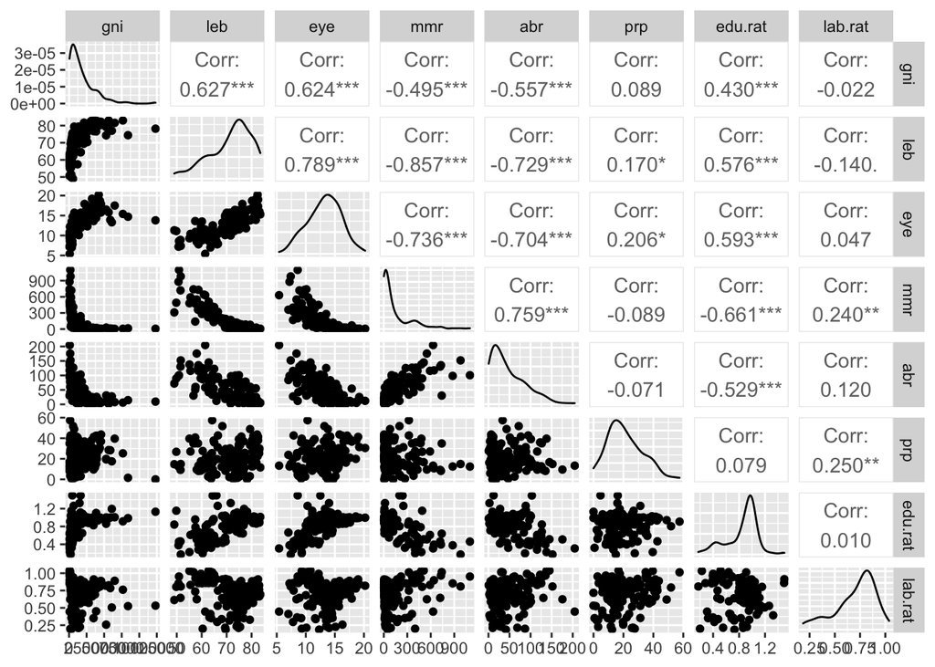

```r
# check the distribution
library(corrplot)
ggpairs(human)
```

```r
cor(human) %>% round(2)
```

```
##           gni   leb   eye   mmr   abr   prp edu.rat lab.rat
## gni      1.00  0.63  0.62 -0.50 -0.56  0.09    0.43   -0.02
## leb      0.63  1.00  0.79 -0.86 -0.73  0.17    0.58   -0.14
## eye      0.62  0.79  1.00 -0.74 -0.70  0.21    0.59    0.05
## mmr     -0.50 -0.86 -0.74  1.00  0.76 -0.09   -0.66    0.24
## abr     -0.56 -0.73 -0.70  0.76  1.00 -0.07   -0.53    0.12
## prp      0.09  0.17  0.21 -0.09 -0.07  1.00    0.08    0.25
## edu.rat  0.43  0.58  0.59 -0.66 -0.53  0.08    1.00    0.01
## lab.rat -0.02 -0.14  0.05  0.24  0.12  0.25    0.01    1.00
```

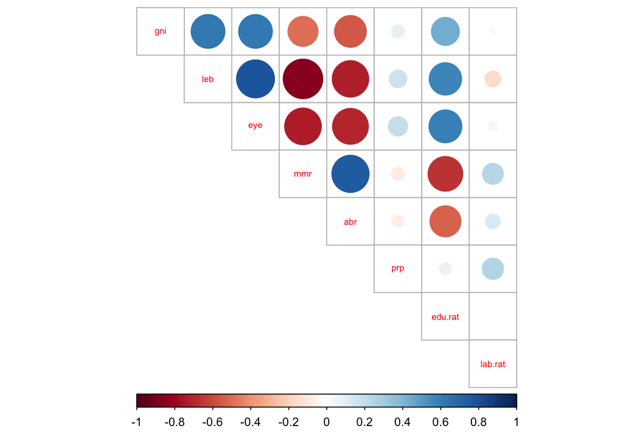

```r
cor(human) %>% corrplot(method="circle", type = "upper", cl.pos = "b", tl.pos = "d", tl.cex = 0.6)
```

```r
summary(human)
```

```
##       gni              leb             eye             mmr
##  Min.   :   581   Min.   :49.00   Min.   : 5.40   Min.   :   1.0
##  1st Qu.:  4198   1st Qu.:66.30   1st Qu.:11.25   1st Qu.:  11.5
##  Median : 12040   Median :74.20   Median :13.50   Median :  49.0
##  Mean   : 17628   Mean   :71.65   Mean   :13.18   Mean   : 149.1
##  3rd Qu.: 24512   3rd Qu.:77.25   3rd Qu.:15.20   3rd Qu.: 190.0
##  Max.   :123124   Max.   :83.50   Max.   :20.20   Max.   :1100.0
##       abr              prp           edu.rat          lab.rat
##  Min.   :  0.60   Min.   : 0.00   Min.   :0.1717   Min.   :0.1857
##  1st Qu.: 12.65   1st Qu.:12.40   1st Qu.:0.7264   1st Qu.:0.5984
##  Median : 33.60   Median :19.30   Median :0.9375   Median :0.7535
##  Mean   : 47.16   Mean   :20.91   Mean   :0.8529   Mean   :0.7074
##  3rd Qu.: 71.95   3rd Qu.:27.95   3rd Qu.:0.9968   3rd Qu.:0.8535
##  Max.   :204.80   Max.   :57.50   Max.   :1.4967   Max.   :1.0380
```

From the plot we can the following:

1. the strong positive correlation is between:
- expected years of education **eye** and life expectancy at birth **leb**: **0.79**
- adolescent birth rate **abr** and maternal mortality ratio **mmr**: **0.76**
2. the strong negative correlation is between:
- maternal mortality ratio **mmr** and life expectancy at birth **leb**: **-0.86**
- adolescent birth rate **abr** and life expectancy at birth **leb**: **-0.73**

Only the expected years of education **eye** variable is close to the normal ditribution, other variables are skewed.

## Principal component analysis (PCA)

Let’s perform principal component analysis for our dataset

```r
# performing principal component analysis (with the SVD method)
pca_human <- prcomp(human)
pca_human
```

```
## Standard deviations (1, .., p=8):
## [1] 1.854416e+04 1.855219e+02 2.518701e+01 1.145441e+01 3.766241e+00
## [6] 1.565912e+00 1.912052e-01 1.591112e-01
##
## Rotation (n x k) = (8 x 8):
##                   PC1           PC2           PC3           PC4           PC5
## gni     -9.999832e-01 -0.0057723054  5.156742e-04 -4.932889e-05 -0.0001135863
## leb     -2.815823e-04  0.0283150248 -1.294971e-02  6.752684e-02  0.9865644425
## eye     -9.562910e-05  0.0075529759 -1.427664e-02  3.313505e-02  0.1431180282
## mmr      5.655734e-03 -0.9916320120 -1.260302e-01  6.100534e-03  0.0266373214
## abr      1.233961e-03 -0.1255502723  9.918113e-01 -5.301595e-03  0.0188618600
## prp     -5.526460e-05  0.0032317269  7.398331e-03  9.971232e-01 -0.0716401914
## edu.rat -5.607472e-06  0.0006713951  3.412027e-05  2.736326e-04 -0.0022935252
## lab.rat  2.331945e-07 -0.0002819357 -5.302884e-04  4.692578e-03  0.0022190154
##                   PC6           PC7           PC8
## gni      2.711698e-05  8.075191e-07 -1.176762e-06
## leb      1.453515e-01 -5.380452e-03  2.281723e-03
## eye     -9.882477e-01  3.826887e-02  7.776451e-03
## mmr     -1.695203e-03 -1.355518e-04  8.371934e-04
## abr     -1.273198e-02  8.641234e-05 -1.707885e-04
## prp      2.309896e-02  2.642548e-03  2.680113e-03
## edu.rat -2.180183e-02 -6.998623e-01  7.139410e-01
## lab.rat -3.264423e-02 -7.132267e-01 -7.001533e-01
```

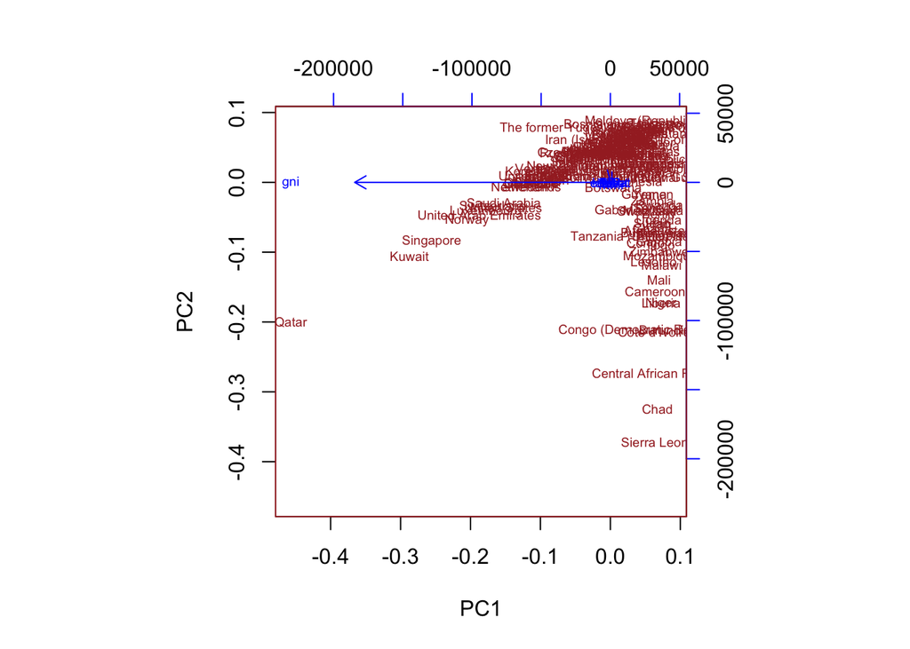

```r
# drawing a biplot of the principal component representation and the original variables
biplot(pca_human, choices = 1:2, cex = c(0.6, 0.6), col = c("brown", "blue"))
```